# Forecasting models for confirmed COVID19 cases

Author

Huiting Wu

Published

March 7, 2025

```r
library(pacman)
p_load(tidyverse, fpp3, COVID19, MASS, purrr)
```

```r
covid_data <- covid19(c("United States"))
```

[output not shown]

```r
covid_data <- covid_data |>  as_tsibble(key = "id", index = "date")
```

> Produce an STL decomposition of the data.

The start date is 2020-01-21 and the end date is 2023-03-23.

There is an increasing trend over the years.

There is a seasonality. There are most confirmed cases in the beginning of a year and then decreasing until the end of the year, Then, there is an increasing in the beginning of the next year.

There are some weekly pattern. There are variations in confirmed cases by weekly.

There is a big step increasing in 2022 and a big step of decreasing in 2023 in the remainder.

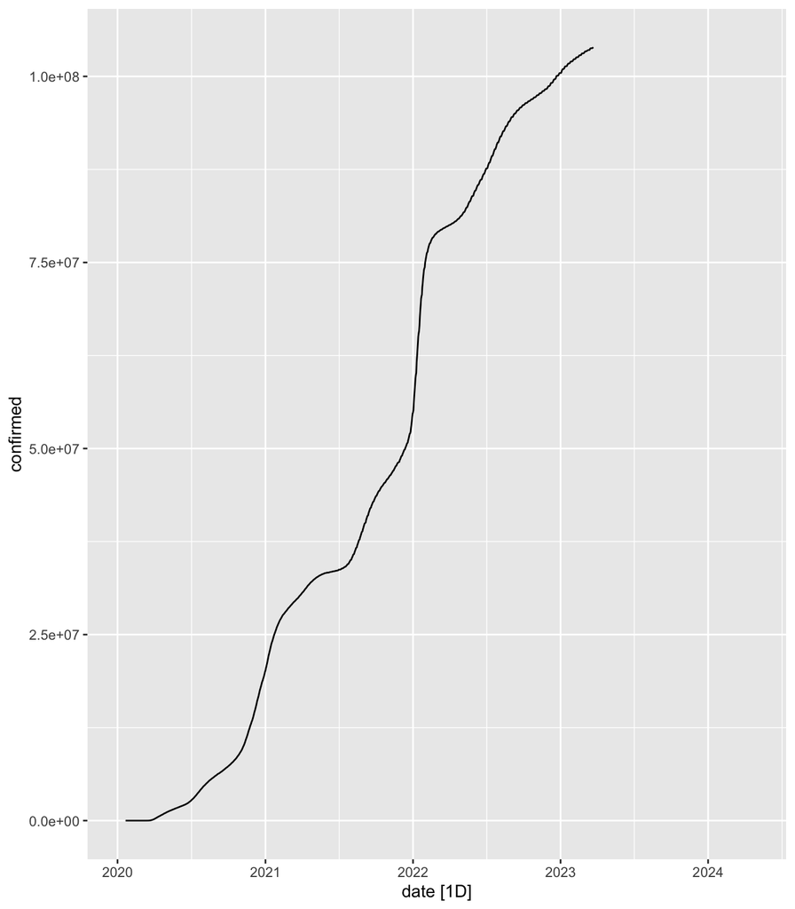

```r
covid_data |> autoplot(confirmed)
```

```r
# filter missing value in confirmed
covid_data <- covid_data  |>
   filter(!is.na(confirmed))

# Check the date range
 range(covid_data$date)
```

```
[1] "2020-01-21" "2023-03-23"
```

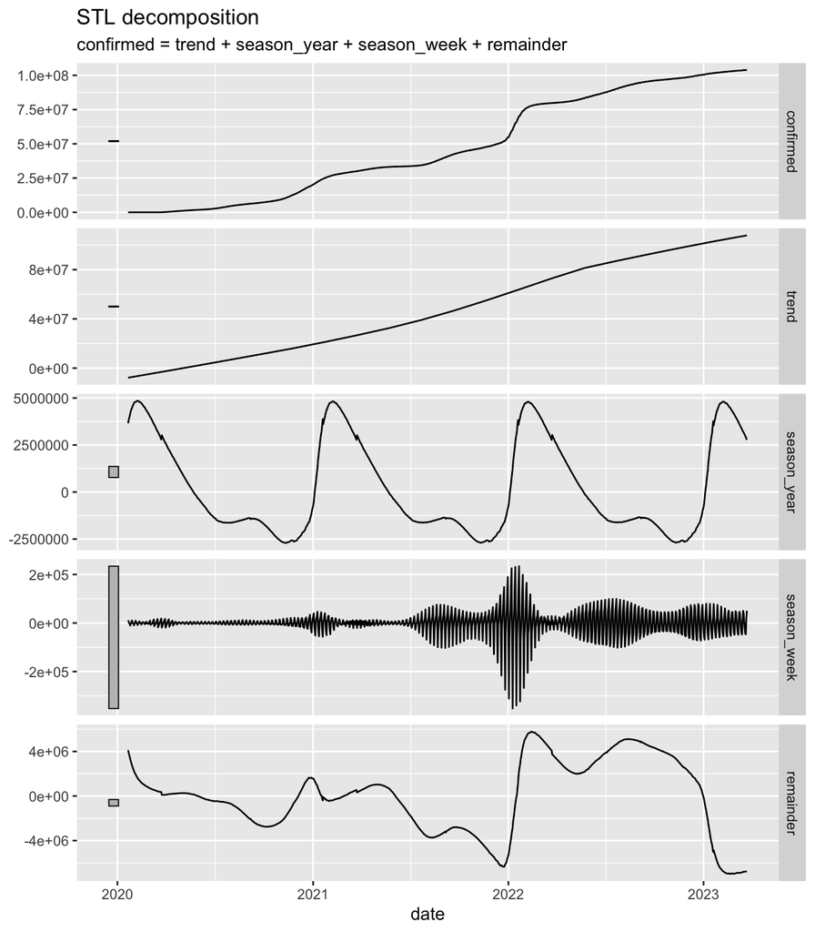

```r
# STL decomposition
covid_data |>
  model(STL(confirmed)) |>
  components() |>
  autoplot()
```

> Transforming

The data need transformation seems there is trend, seasonality, and the variability is not constant.

The maximum lambda is 0.67 which is closer to 0.5

A square root transformation is applied.

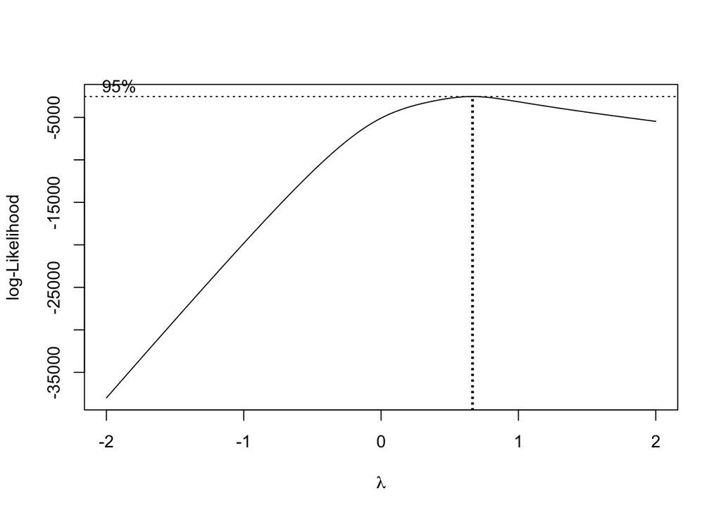

```r
# check transformation
b <- boxcox(lm(confirmed ~ date, data = covid_data))
```

```r
b$x[which.max(b$y)]
```

```
[1] 0.6666667
```

> Stationary

The data is not stationary. A square root transformation, a weekly differencing, and a 1st differencing applied. The data is approximately stationary with constant mean of confirmed cases.

```r
# check if data is stationary
covid_data |>
  features(sqrt(confirmed), unitroot_kpss)
```

| id | kpss_stat | kpss_pvalue |
| --- | --- | --- |
| 59a13ceb | 14.21952 | 0.01 |

```r
# check number of differencing
covid_data |>
  features(sqrt(confirmed), unitroot_ndiffs)
```

| id | ndiffs |
| --- | --- |
| 59a13ceb | 2 |

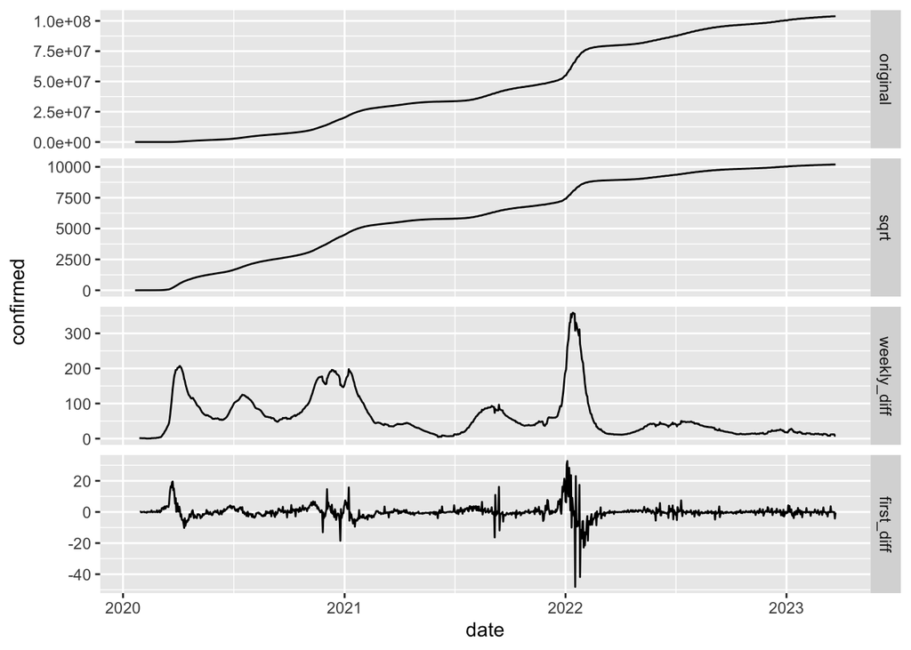

```r
# check stationary

# transformation, seasonal diff, 1st diff
covid_data |> transmute(
  original = confirmed,
  sqrt = sqrt(confirmed),
  weekly_diff = difference(sqrt(confirmed), 7),
  first_diff = difference(difference(sqrt(confirmed), 7), 1)) |>
   pivot_longer(-date, names_to = "Type", values_to = "confirmed") |>
   mutate(Type = factor(Type, levels = c(
     "original",
     "sqrt",
     "weekly_diff",
     "first_diff"
   ))) |>
 ggplot(aes(x = date, y = confirmed)) +
   geom_line() +
   facet_grid(vars(Type), scales = "free_y")
```

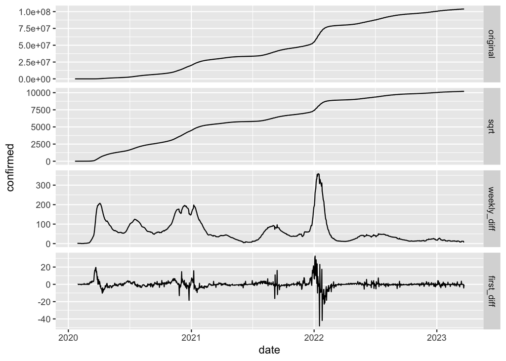

```r
# seasonal diff, 1st diff
covid_data |> transmute(
  original = confirmed,
  sqrt = sqrt(confirmed),
  weekly_diff = difference(sqrt(confirmed), 7),
  first_diff = difference(difference(sqrt(confirmed), 7), 1)) |>
   pivot_longer(-date, names_to = "Type", values_to = "confirmed") |>
   mutate(Type = factor(Type, levels = c(
     "original",
     "sqrt",
     "weekly_diff",
     "first_diff"
   ))) |>
 ggplot(aes(x = date, y = confirmed)) +
   geom_line() +
   facet_grid(vars(Type), scales = "free_y")
```

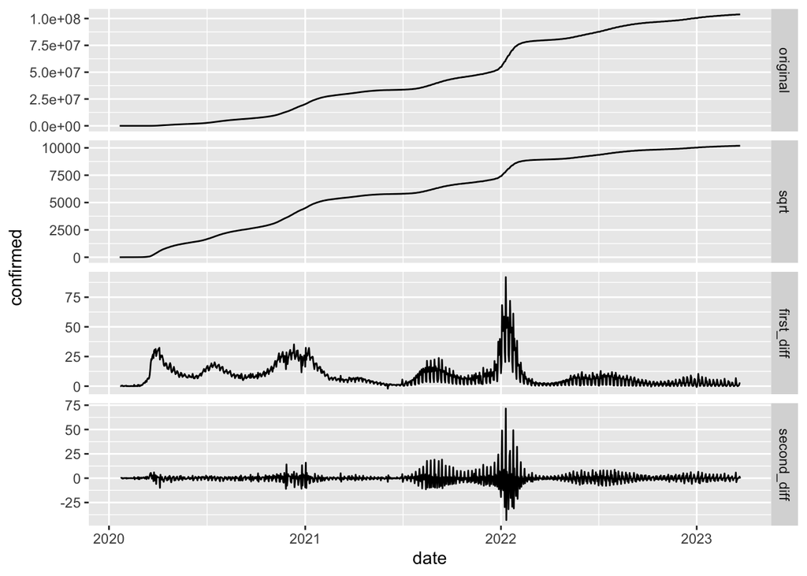

```r
# 1st diff, 2nd diff
covid_data |> transmute(
  original = confirmed,
  sqrt = sqrt(confirmed),
  first_diff = difference(sqrt(confirmed), 1),
  second_diff = difference(difference(sqrt(confirmed), 1), 1)) |>
   pivot_longer(-date, names_to = "Type", values_to = "confirmed") |>
   mutate(Type = factor(Type, levels = c(
     "original",
     "sqrt",
     "first_diff",
     "second_diff"
   ))) |>
 ggplot(aes(x = date, y = confirmed)) +
   geom_line() +
   facet_grid(vars(Type), scales = "free_y")
```

> ARIMA models

Comparing ARIMA(3,1,0)(1,1,0) and ARIMA(3,1,0)(0,1,1), the lower AICc is the model ARIMA(3,1,0)(0,1,1) which is slightly smaller. The best model is ARIMA(3,1,0)(0,1,1).

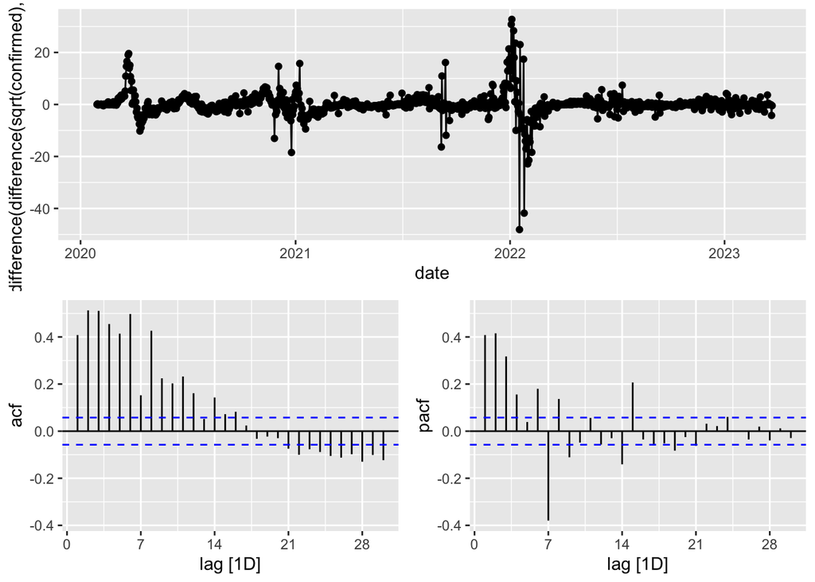

```r
covid_data |>
  gg_tsdisplay(difference(difference(sqrt(confirmed), 7), 1),
               plot_type = "partial")
```

```r
covid_data |> model(arima310011 = ARIMA(sqrt(confirmed) ~ pdq(3,1,0) + PDQ(0,1,1)),
                    arima310110 = ARIMA(sqrt(confirmed) ~ pdq(3,1,0) + PDQ(1,1,0))) |>
  report()
```

| id | .model | sigma2 | log_lik | AIC | AICc | BIC | ar_roots | ma_roots |
| --- | --- | --- | --- | --- | --- | --- | --- | --- |
| 59a13ceb | arima310011 | 10.77631 | -2997.796 | 6005.593 | 6005.645 | 6030.830 |  |  |
| 59a13ceb | arima310110 | 10.91750 | -3005.140 | 6020.279 | 6020.332 | 6045.517 |  |  |

> Estimate the parameters of the best model

The estimate for parameters are:

$\phi_1$: 1.8125

$\phi_2$: -0.8293

$\theta_1$: -1.6349

$\theta_2$: 0.7566

$\Theta_1$: -0.4895

$\Theta_2$: 0.0647

$sigma^2$: 9.944

The residuals of ARIMA(3,1,0)(0,1,1) model has some pattern but overall there is no trend. There are some other information is not getting by the model. The best model is ARIMA(2,1,2)(0,1,2)[7]. There are less significant ACF of residuals. The histogram of the residual looks approximately normal.

```r
# ARIMA(3,1,0)(1,1,0)
fit <- covid_data |> model(ARIMA(sqrt(confirmed) ~ pdq(3,1,0) + PDQ(0,1,1)))
fit |> report()
```

```
Series: confirmed
Model: ARIMA(3,1,0)(0,1,1)[7]
Transformation: sqrt(confirmed)

Coefficients:
         ar1     ar2     ar3     sma1
      0.2679  0.2968  0.3104  -0.4177
s.e.  0.0307  0.0285  0.0280   0.0321

sigma^2 estimated as 10.78:  log likelihood=-2997.8
AIC=6005.59   AICc=6005.65   BIC=6030.83
```

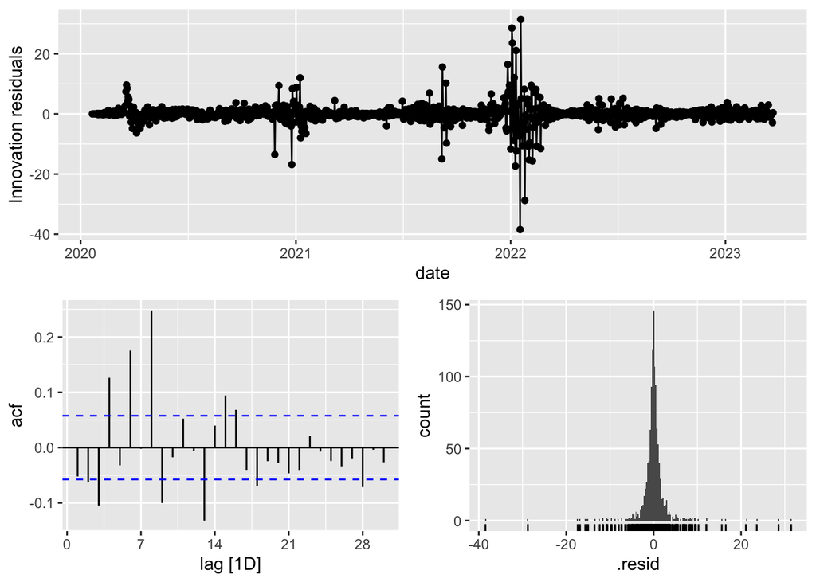

```r
fit |> gg_tsresiduals()
```

```r
# better model
best_fit <- covid_data |> model(ARIMA(sqrt(confirmed)))
best_fit |> report()
```

```
Series: confirmed
Model: ARIMA(2,1,2)(0,1,2)[7]
Transformation: sqrt(confirmed)

Coefficients:
         ar1      ar2      ma1     ma2     sma1    sma2
      1.8125  -0.8293  -1.6349  0.7566  -0.4895  0.0647
s.e.  0.0487   0.0469   0.0371  0.0230   0.0318  0.0346

sigma^2 estimated as 9.944:  log likelihood=-2950.76
AIC=5915.53   AICc=5915.62   BIC=5950.86
```

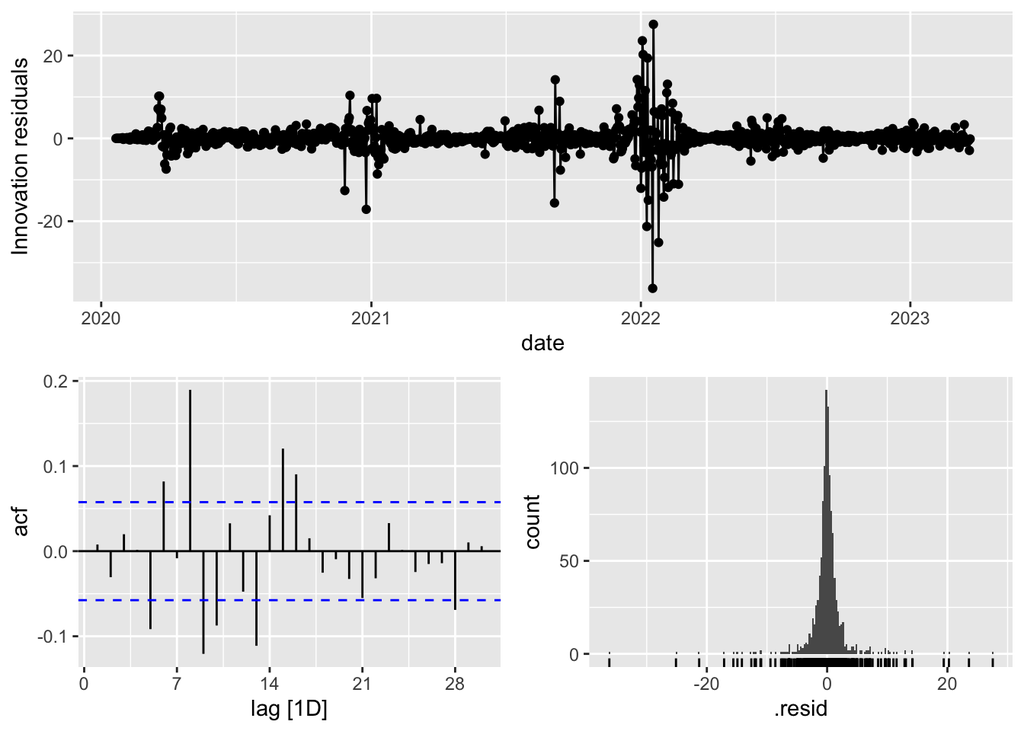

```r
best_fit |> gg_tsresiduals()
```

```r
fcast <- forecast(best_fit, h = 25)
fcast
```

| id | .model | date | confirmed | .mean |
| --- | --- | --- | --- | --- |
| 59a13ceb | ARIMA(sqrt(confirmed)) | 2023-03-24 |  | 103917422 |
| 59a13ceb | ARIMA(sqrt(confirmed)) | 2023-03-25 |  | 103899278 |
| 59a13ceb | ARIMA(sqrt(confirmed)) | 2023-03-26 |  | 103877590 |
| 59a13ceb | ARIMA(sqrt(confirmed)) | 2023-03-27 |  | 103863825 |
| 59a13ceb | ARIMA(sqrt(confirmed)) | 2023-03-28 |  | 103856746 |
| 59a13ceb | ARIMA(sqrt(confirmed)) | 2023-03-29 |  | 103911395 |
| 59a13ceb | ARIMA(sqrt(confirmed)) | 2023-03-30 |  | 103933306 |
| 59a13ceb | ARIMA(sqrt(confirmed)) | 2023-03-31 |  | 103919056 |
| 59a13ceb | ARIMA(sqrt(confirmed)) | 2023-04-01 |  | 103883004 |
| 59a13ceb | ARIMA(sqrt(confirmed)) | 2023-04-02 |  | 103846238 |

[output cut: 15 more lines]

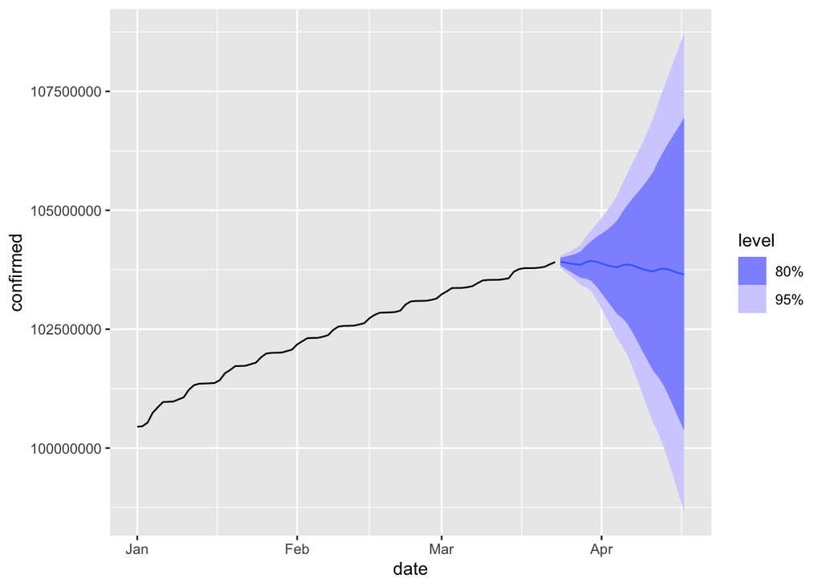

```r
fcast |>
  autoplot(covid_data |> filter_index("2023-01-01" ~ .))
```